# Modelo machine learning - Previsão de casas - AMES

# Exploratory Data Analysis (EDA)

**Desafio Técnico**

- **Questão 1**

Quando você obtém seus dados pela primeira vez, é muito tentador começar imediatamente a ajustar os modelos e avaliar o desempenho deles. No entanto, antes de começar a modelar, é absolutamente essencial explorar a estrutura dos dados e os relacionamentos entre as variáveis no conjunto de dados. Faça um EDA detalhado do conjunto de dados ames_train, para aprender sobre a estrutura dos dados e os relacionamentos entre as variáveis no conjunto de dados.

- **Questão 2**

Depois de ter explorado completamente, certifique-se de criar pelo menos quatro gráficos que você achou mais informativos durante seu processo de EDA e explique brevemente o que você aprendeu com cada um (por que você achou cada informativo).

- **Questão 3**

Na construção de um modelo, geralmente é útil começar criando um modelo inicial simples e intuitivo com base nos resultados da análise exploratória de dados. Você pode sentir vontade de apresentar habilidades estatísticas mais avançadas. Por esse motivo, estamos fornecendo dados de teste no conjunto de dados ames_test para que você possa construir um modelo simples para prever os preços das casas com base nos dados disponíveis no conjunto de dados de treinamento. Use sua imaginação.

**Nota: O objetivo não é identificar o “melhor” modelo possível, mas escolher um ponto de partida razoável e compreensível**

# Regras de Envio

Para que o seu desafio seja analisado, você deverá atender às seguintes regras:

- Respeitar a data limite informada no email
- Fazer um projeto utilizando a linguagem python
- O código deverá ser entregue como um notebook no formato .ipynb, identificando adequadamente as questões, com comentários e explicações.

# Avaliação

Iremos avaliar a forma que você resolveu as questões, sua criatividade, insights e passos que tomou para obtenção de resultados, assim como os comentários e forma como desenvolveu os códigos. Dessa forma sugerimos a originalidade e criatividade para resolução das questões.

# 0 - Importação das bibliotecas

```python
# Versão do python
from platform import python_version

print('Versão python neste Jupyter Notebook:', python_version())
```

```
Versão python neste Jupyter Notebook: 3.9.7
```

```python
# Importação das bibliotecas

import pandas as pd # Pandas carregamento csv
import numpy as np # Numpy para carregamento cálculos em arrays multidimensionais

# Visualização de dados
import seaborn as sns
import matplotlib as m
import matplotlib as mpl
import matplotlib.pyplot as plt
import plotly
import plotly.express as px

# Carregar as versões das bibliotecas
import watermark

# Warnings retirar alertas
import warnings
warnings.filterwarnings("ignore")
```

```python
# Versões das bibliotecas

%reload_ext watermark
%watermark -a "Versões das bibliotecas" --iversions
```

```
Author: Versões das bibliotecas

pandas    : 1.3.4
watermark : 2.3.0
seaborn   : 0.11.2
matplotlib: 3.4.3
numpy     : 1.20.3
plotly    : 5.5.0
```

```python
# Configuração para os gráficos largura e layout dos graficos

plt.rcParams["figure.figsize"] = (25, 20)

plt.style.use('fivethirtyeight')
pd.set_option('display.expand_frame_repr', False)
pd.set_option('display.max_columns', 500)
pd.set_option('display.width', 1000)

m.rcParams['axes.labelsize'] = 25
m.rcParams['xtick.labelsize'] = 25
m.rcParams['ytick.labelsize'] = 25
m.rcParams['text.color'] = 'k'
```

# 0.1) Base de dados

```python
# Carregando a base de dados
data_train = pd.read_csv("ames_train.csv", sep = ";")
data_test = pd.read_csv("ames_test.csv", sep = ";")
```

# 0.2) Descrição dados

- Verificação de linhas colunas informaçãos dos dados e tipos de variáveis. Valores das colunas verficando dados nulos ou vazios.

```python
# Exibido 5 primeiros dados de data_train

data_train.head()
```

|  | Unnamed: 0 | PID | area | price | MS.SubClass | MS.Zoning | Lot.Frontage | Lot.Area | Street | Alley | Lot.Shape | Land.Contour | Utilities | Lot.Config | Land.Slope | Neighborhood | Condition.1 | Condition.2 | Bldg.Type | House.Style | Overall.Qual | Overall.Cond | Year.Built | Year.Remod.Add | Roof.Style | Roof.Matl | Exterior.1st | Exterior.2nd | Mas.Vnr.Type | … |
| --- | --- | --- | --- | --- | --- | --- | --- | --- | --- | --- | --- | --- | --- | --- | --- | --- | --- | --- | --- | --- | --- | --- | --- | --- | --- | --- | --- | --- | --- | --- |
| 0 | 1 | 40000 | 856 | 126000 | 30 | RL | NaN | 7890 | Pave | NaN | Reg | Lvl | AllPub | Corner | Gtl | SWISU | Norm | Norm | 1Fam | 1Story | 6 | 6 | 1939 | 1950 | Gable | CompShg | Wd Sdng | Wd Sdng | None | … |
| 1 | 2 | 40001 | 1049 | 139500 | 120 | RL | 42.0 | 4235 | Pave | NaN | Reg | Lvl | AllPub | Inside | Gtl | Edwards | Norm | Norm | TwnhsE | 1Story | 5 | 5 | 1984 | 1984 | Gable | CompShg | HdBoard | HdBoard | BrkFace | … |
| 2 | 3 | 40002 | 1001 | 124900 | 30 | C (all) | 60.0 | 6060 | Pave | NaN | Reg | Lvl | AllPub | Inside | Gtl | IDOTRR | Norm | Norm | 1Fam | 1Story | 5 | 9 | 1930 | 2007 | Hip | CompShg | MetalSd | MetalSd | None | … |
| 3 | 4 | 40003 | 1039 | 114000 | 70 | RL | 80.0 | 8146 | Pave | NaN | Reg | Lvl | AllPub | Corner | Gtl | OldTown | Norm | Norm | 1Fam | 2Story | 4 | 8 | 1900 | 2003 | Gable | CompShg | MetalSd | MetalSd | None | … |
| 4 | 5 | 40004 | 1665 | 227000 | 60 | RL | 70.0 | 8400 | Pave | NaN | Reg | Lvl | AllPub | Inside | Gtl | NWAmes | Norm | Norm | 1Fam | 2Story | 8 | 6 | 2001 | 2001 | Gable | CompShg | VinylSd | VinylSd | None | … |

```python
# Exibido 5 últimos dados de data_train

data_train.tail()
```

|  | Unnamed: 0 | PID | area | price | MS.SubClass | MS.Zoning | Lot.Frontage | Lot.Area | Street | Alley | Lot.Shape | Land.Contour | Utilities | Lot.Config | Land.Slope | Neighborhood | Condition.1 | Condition.2 | Bldg.Type | House.Style | Overall.Qual | Overall.Cond | Year.Built | Year.Remod.Add | Roof.Style | Roof.Matl | Exterior.1st | Exterior.2nd | Mas.Vnr.Type | … |
| --- | --- | --- | --- | --- | --- | --- | --- | --- | --- | --- | --- | --- | --- | --- | --- | --- | --- | --- | --- | --- | --- | --- | --- | --- | --- | --- | --- | --- | --- | --- |
| 995 | 996 | 40995 | 848 | 145000 | 120 | RM | NaN | 4426 | Pave | NaN | Reg | Lvl | AllPub | Inside | Gtl | CollgCr | Norm | Norm | TwnhsE | 1Story | 6 | 5 | 2004 | 2004 | Gable | CompShg | VinylSd | VinylSd | BrkFace | … |
| 996 | 997 | 40996 | 1576 | 197000 | 60 | FV | 65.0 | 8125 | Pave | NaN | Reg | Lvl | AllPub | Inside | Gtl | Somerst | Norm | Norm | 1Fam | 2Story | 7 | 5 | 2006 | 2006 | Gable | CompShg | VinylSd | VinylSd | None | … |
| 997 | 998 | 40997 | 1728 | 84900 | 90 | RL | 98.0 | 13260 | Pave | NaN | IR1 | Lvl | AllPub | Inside | Gtl | NAmes | Norm | Norm | Duplex | 1Story | 5 | 6 | 1962 | 2001 | Hip | CompShg | HdBoard | HdBoard | BrkFace | … |
| 998 | 999 | 40998 | 1352 | 158000 | 60 | RL | 80.0 | 9364 | Pave | NaN | Reg | Lvl | AllPub | Corner | Gtl | Sawyer | Norm | Norm | 1Fam | 2Story | 6 | 7 | 1969 | 1969 | Gable | CompShg | HdBoard | HdBoard | Stone | … |
| 999 | 1000 | 40999 | 912 | 156000 | 85 | RL | NaN | 7540 | Pave | NaN | IR1 | Lvl | AllPub | CulDSac | Gtl | Mitchel | Norm | Norm | 1Fam | SFoyer | 6 | 6 | 1978 | 1978 | Gable | CompShg | VinylSd | VinylSd | None | … |

```python
# Exibido 5 primeiros dados de data_test

data_test.head()
```

|  | Unnamed: 0 | PID | area | price | MS.SubClass | MS.Zoning | Lot.Frontage | Lot.Area | Street | Alley | Lot.Shape | Land.Contour | Utilities | Lot.Config | Land.Slope | Neighborhood | Condition.1 | Condition.2 | Bldg.Type | House.Style | Overall.Qual | Overall.Cond | Year.Built | Year.Remod.Add | Roof.Style | Roof.Matl | Exterior.1st | Exterior.2nd | Mas.Vnr.Type | … |
| --- | --- | --- | --- | --- | --- | --- | --- | --- | --- | --- | --- | --- | --- | --- | --- | --- | --- | --- | --- | --- | --- | --- | --- | --- | --- | --- | --- | --- | --- | --- |
| 0 | 1 | 50001 | 2000 | 305900 | 20 | RL | 80.0 | 10386 | Pave | NaN | Reg | Lvl | AllPub | Inside | Gtl | CollgCr | Norm | Norm | 1Fam | 1Story | 8 | 5 | 2004 | 2005 | Gable | CompShg | CemntBd | CmentBd | Stone | … |
| 1 | 2 | 50002 | 1839 | 257500 | 20 | RL | 110.0 | 14442 | Pave | NaN | Reg | Lvl | AllPub | Inside | Gtl | Crawfor | Norm | Norm | 1Fam | 1Story | 6 | 7 | 1957 | 2004 | Hip | CompShg | CemntBd | CmentBd | BrkFace | … |
| 2 | 3 | 50003 | 882 | 116000 | 20 | RL | 60.0 | 11556 | Pave | NaN | Reg | Lvl | AllPub | Inside | Gtl | NAmes | Norm | Norm | 1Fam | 1Story | 5 | 6 | 1952 | 1952 | Gable | CompShg | MetalSd | MetalSd | Stone | … |
| 3 | 4 | 50004 | 1152 | 143450 | 20 | RL | 78.0 | 11700 | Pave | NaN | Reg | Lvl | AllPub | Inside | Gtl | NWAmes | RRAn | Norm | 1Fam | 1Story | 6 | 6 | 1968 | 1968 | Gable | CompShg | MetalSd | MetalSd | BrkFace | … |
| 4 | 5 | 50005 | 1561 | 277500 | 120 | RL | 60.0 | 7313 | Pave | NaN | Reg | Lvl | AllPub | Inside | Gtl | NridgHt | Norm | Norm | TwnhsE | 1Story | 9 | 5 | 2005 | 2005 | Hip | CompShg | MetalSd | MetalSd | BrkFace | … |

```python
# Exibido 5 últimos dados de data_train

data_test.tail()
```

|  | Unnamed: 0 | PID | area | price | MS.SubClass | MS.Zoning | Lot.Frontage | Lot.Area | Street | Alley | Lot.Shape | Land.Contour | Utilities | Lot.Config | Land.Slope | Neighborhood | Condition.1 | Condition.2 | Bldg.Type | House.Style | Overall.Qual | Overall.Cond | Year.Built | Year.Remod.Add | Roof.Style | Roof.Matl | Exterior.1st | Exterior.2nd | Mas.Vnr.Type | … |
| --- | --- | --- | --- | --- | --- | --- | --- | --- | --- | --- | --- | --- | --- | --- | --- | --- | --- | --- | --- | --- | --- | --- | --- | --- | --- | --- | --- | --- | --- | --- |
| 812 | 813 | 50813 | 848 | 143750 | 120 | RM | NaN | 4435 | Pave | NaN | Reg | Lvl | AllPub | Inside | Gtl | CollgCr | Norm | Norm | TwnhsE | 1Story | 6 | 5 | 2003 | 2003 | Gable | CompShg | VinylSd | VinylSd | BrkFace | … |
| 813 | 814 | 50814 | 840 | 87000 | 45 | RM | 55.0 | 4388 | Pave | NaN | IR1 | Bnk | AllPub | Inside | Gtl | OldTown | Feedr | Norm | 1Fam | 1.5Unf | 5 | 7 | 1930 | 1950 | Gable | CompShg | WdShing | Wd Sdng | None | … |
| 814 | 815 | 50815 | 2541 | 349265 | 60 | RL | 98.0 | 12328 | Pave | NaN | IR1 | Lvl | AllPub | Inside | Gtl | StoneBr | Norm | Norm | 1Fam | 2Story | 8 | 5 | 2005 | 2005 | Hip | CompShg | VinylSd | VinylSd | Stone | … |
| 815 | 816 | 50816 | 1682 | 174000 | 20 | RL | 80.0 | 10400 | Pave | NaN | Reg | Lvl | AllPub | Inside | Gtl | NWAmes | Norm | Norm | 1Fam | 1Story | 7 | 6 | 1970 | 1970 | Hip | CompShg | Plywood | Plywood | BrkFace | … |
| 816 | 817 | 50817 | 1717 | 194000 | 50 | RL | 80.0 | 12400 | Pave | NaN | Reg | HLS | AllPub | Inside | Mod | Crawfor | Norm | Norm | 1Fam | 1.5Fin | 5 | 6 | 1940 | 1950 | Gable | CompShg | Wd Sdng | Wd Sdng | None | … |

```python
# Número de linhas e colunas

data_train.shape
```

```
(1000, 82)
```

```python
# Verificando informações das variaveis

data_train.info()
```

```
<class 'pandas.core.frame.DataFrame'>
RangeIndex: 1000 entries, 0 to 999
Data columns (total 82 columns):
 #   Column           Non-Null Count  Dtype
---  ------           --------------  -----
 0   Unnamed: 0       1000 non-null   int64
 1   PID              1000 non-null   int64
 2   area             1000 non-null   int64
 3   price            1000 non-null   int64
 4   MS.SubClass      1000 non-null   int64
 5   MS.Zoning        1000 non-null   object
 6   Lot.Frontage     833 non-null    float64
 7   Lot.Area         1000 non-null   int64
 8   Street           1000 non-null   object
 9   Alley            67 non-null     object
```

[output cut: 74 more lines]

```python
# Exibido tipos de dados

data_train.dtypes
```

```
Unnamed: 0         int64
PID                int64
area               int64
price              int64
MS.SubClass        int64
                   ...
Misc.Val           int64
Mo.Sold            int64
Yr.Sold            int64
Sale.Type         object
Sale.Condition    object
Length: 82, dtype: object
```

```python
# Total de colunas e linhas - data_train

print("Números de linhas: {}" .format(data_train.shape[0]))
print("Números de colunas: {}" .format(data_train.shape[1]))
```

```
Números de linhas: 1000
Números de colunas: 82
```

```python
# Total de colunas e linhas - data_test

print("Números de linhas: {}" .format(data_test.shape[0]))
print("Números de colunas: {}" .format(data_test.shape[1]))
```

```
Números de linhas: 817
Números de colunas: 82
```

```python
# Exibindo valores ausentes e valores únicos

print("\nMissing values :  ", data_train.isnull().sum().values.sum())
print("\nUnique values :  \n",data_train.nunique())
```

```
Missing values :   4728

Unique values :
 Unnamed: 0        1000
PID               1000
area               686
price              535
MS.SubClass         15
                  ...
Misc.Val            18
Mo.Sold             12
Yr.Sold              5
Sale.Type           10
Sale.Condition       6
Length: 82, dtype: int64
```

```python
# Exibindo valores ausentes e valores únicos

print("\nMissing values :  ", data_test.isnull().sum().values.sum())
print("\nUnique values :  \n",data_test.nunique())
```

```
Missing values :   3846

Unique values :
 Unnamed: 0        817
PID               817
area              595
price             423
MS.SubClass        15
                 ...
Misc.Val           15
Mo.Sold            12
Yr.Sold             5
Sale.Type           4
Sale.Condition      1
Length: 82, dtype: int64
```

# 0.3) - Limpeza da base de dados

```python
# Dados faltantes coluna óbitos

data = data_train[data_train["price"].notnull()]
data.isna().sum()
```

```
Unnamed: 0        0
PID               0
area              0
price             0
MS.SubClass       0
                 ..
Misc.Val          0
Mo.Sold           0
Yr.Sold           0
Sale.Type         0
Sale.Condition    0
Length: 82, dtype: int64
```

```python
# Removendo dados ausentes do dataset

data = data_train.dropna()
data_train.head()
```

|  | Unnamed: 0 | PID | area | price | MS.SubClass | MS.Zoning | Lot.Frontage | Lot.Area | Street | Alley | Lot.Shape | Land.Contour | Utilities | Lot.Config | Land.Slope | Neighborhood | Condition.1 | Condition.2 | Bldg.Type | House.Style | Overall.Qual | Overall.Cond | Year.Built | Year.Remod.Add | Roof.Style | Roof.Matl | Exterior.1st | Exterior.2nd | Mas.Vnr.Type | … |
| --- | --- | --- | --- | --- | --- | --- | --- | --- | --- | --- | --- | --- | --- | --- | --- | --- | --- | --- | --- | --- | --- | --- | --- | --- | --- | --- | --- | --- | --- | --- |
| 0 | 1 | 40000 | 856 | 126000 | 30 | RL | NaN | 7890 | Pave | NaN | Reg | Lvl | AllPub | Corner | Gtl | SWISU | Norm | Norm | 1Fam | 1Story | 6 | 6 | 1939 | 1950 | Gable | CompShg | Wd Sdng | Wd Sdng | None | … |
| 1 | 2 | 40001 | 1049 | 139500 | 120 | RL | 42.0 | 4235 | Pave | NaN | Reg | Lvl | AllPub | Inside | Gtl | Edwards | Norm | Norm | TwnhsE | 1Story | 5 | 5 | 1984 | 1984 | Gable | CompShg | HdBoard | HdBoard | BrkFace | … |
| 2 | 3 | 40002 | 1001 | 124900 | 30 | C (all) | 60.0 | 6060 | Pave | NaN | Reg | Lvl | AllPub | Inside | Gtl | IDOTRR | Norm | Norm | 1Fam | 1Story | 5 | 9 | 1930 | 2007 | Hip | CompShg | MetalSd | MetalSd | None | … |
| 3 | 4 | 40003 | 1039 | 114000 | 70 | RL | 80.0 | 8146 | Pave | NaN | Reg | Lvl | AllPub | Corner | Gtl | OldTown | Norm | Norm | 1Fam | 2Story | 4 | 8 | 1900 | 2003 | Gable | CompShg | MetalSd | MetalSd | None | … |
| 4 | 5 | 40004 | 1665 | 227000 | 60 | RL | 70.0 | 8400 | Pave | NaN | Reg | Lvl | AllPub | Inside | Gtl | NWAmes | Norm | Norm | 1Fam | 2Story | 8 | 6 | 2001 | 2001 | Gable | CompShg | VinylSd | VinylSd | None | … |

```python
# Sum() Retorna a soma dos valores sobre o eixo solicitado
# Isna() Detecta valores ausentes

data_train.isna().sum()
```

```
Unnamed: 0        0
PID               0
area              0
price             0
MS.SubClass       0
                 ..
Misc.Val          0
Mo.Sold           0
Yr.Sold           0
Sale.Type         0
Sale.Condition    0
Length: 82, dtype: int64
```

```python
# Retorna a soma dos valores sobre o eixo solicitado
# Detecta valores não ausentes para um objeto semelhante a uma matriz.

data_train.notnull().sum()
```

```
Unnamed: 0        1000
PID               1000
area              1000
price             1000
MS.SubClass       1000
                  ...
Misc.Val          1000
Mo.Sold           1000
Yr.Sold           1000
Sale.Type         1000
Sale.Condition    1000
Length: 82, dtype: int64
```

```python
# Total de número duplicados

data_train.duplicated()
```

```
0      False
1      False
2      False
3      False
4      False
       ...
995    False
996    False
997    False
998    False
999    False
Length: 1000, dtype: bool
```

```python
# Dados faltantes

data_train.fillna(0, inplace=True)
data_train.head()
```

|  | Unnamed: 0 | PID | area | price | MS.SubClass | MS.Zoning | Lot.Frontage | Lot.Area | Street | Alley | Lot.Shape | Land.Contour | Utilities | Lot.Config | Land.Slope | Neighborhood | Condition.1 | Condition.2 | Bldg.Type | House.Style | Overall.Qual | Overall.Cond | Year.Built | Year.Remod.Add | Roof.Style | Roof.Matl | Exterior.1st | Exterior.2nd | Mas.Vnr.Type | … |
| --- | --- | --- | --- | --- | --- | --- | --- | --- | --- | --- | --- | --- | --- | --- | --- | --- | --- | --- | --- | --- | --- | --- | --- | --- | --- | --- | --- | --- | --- | --- |
| 0 | 1 | 40000 | 856 | 126000 | 30 | RL | 0.0 | 7890 | Pave | 0 | Reg | Lvl | AllPub | Corner | Gtl | SWISU | Norm | Norm | 1Fam | 1Story | 6 | 6 | 1939 | 1950 | Gable | CompShg | Wd Sdng | Wd Sdng | None | … |
| 1 | 2 | 40001 | 1049 | 139500 | 120 | RL | 42.0 | 4235 | Pave | 0 | Reg | Lvl | AllPub | Inside | Gtl | Edwards | Norm | Norm | TwnhsE | 1Story | 5 | 5 | 1984 | 1984 | Gable | CompShg | HdBoard | HdBoard | BrkFace | … |
| 2 | 3 | 40002 | 1001 | 124900 | 30 | C (all) | 60.0 | 6060 | Pave | 0 | Reg | Lvl | AllPub | Inside | Gtl | IDOTRR | Norm | Norm | 1Fam | 1Story | 5 | 9 | 1930 | 2007 | Hip | CompShg | MetalSd | MetalSd | None | … |
| 3 | 4 | 40003 | 1039 | 114000 | 70 | RL | 80.0 | 8146 | Pave | 0 | Reg | Lvl | AllPub | Corner | Gtl | OldTown | Norm | Norm | 1Fam | 2Story | 4 | 8 | 1900 | 2003 | Gable | CompShg | MetalSd | MetalSd | None | … |
| 4 | 5 | 40004 | 1665 | 227000 | 60 | RL | 70.0 | 8400 | Pave | 0 | Reg | Lvl | AllPub | Inside | Gtl | NWAmes | Norm | Norm | 1Fam | 2Story | 8 | 6 | 2001 | 2001 | Gable | CompShg | VinylSd | VinylSd | None | … |

```python
# Períodos faltantes

sorted(data_train['price'].unique())
```

[output not shown]

[output cut: 480 more lines]

[output not shown]

# Questão 1

Quando você obtém seus dados pela primeira vez, é muito tentador começar imediatamente a ajustar os modelos e avaliar o desempenho deles. No entanto, antes de começar a modelar, é absolutamente essencial explorar a estrutura dos dados e os relacionamentos entre as variáveis no conjunto de dados. Faça um EDA detalhado do conjunto de dados ames_train, para aprender sobre a estrutura dos dados e os relacionamentos entre as variáveis no conjunto de dados.

# 0.4) Estatística descritiva

```python
# Exibindo estatísticas descritivas visualizar alguns detalhes estatísticos básicos como percentil, média, padrão, etc.
# De um quadro de dados ou uma série de valores numéricos.

data_train.describe().T
```

|  | count | mean | std | min | 25% | 50% | 75% | max |
| --- | --- | --- | --- | --- | --- | --- | --- | --- |
| Unnamed: 0 | 1000.0 | 500.500 | 288.819436 | 1.0 | 250.75 | 500.5 | 750.25 | 1000.0 |
| PID | 1000.0 | 40499.500 | 288.819436 | 40000.0 | 40249.75 | 40499.5 | 40749.25 | 40999.0 |
| area | 1000.0 | 1476.615 | 505.174189 | 334.0 | 1092.00 | 1411.0 | 1743.25 | 4676.0 |
| price | 1000.0 | 181190.076 | 81909.787799 | 12789.0 | 129762.50 | 159467.0 | 213000.00 | 615000.0 |
| MS.SubClass | 1000.0 | 57.150 | 43.020673 | 20.0 | 20.00 | 50.0 | 70.00 | 190.0 |
| Lot.Frontage | 1000.0 | 57.656 | 34.033689 | 0.0 | 42.00 | 62.0 | 78.00 | 313.0 |
| Lot.Area | 1000.0 | 10352.406 | 9827.841077 | 1470.0 | 7314.00 | 9317.0 | 11649.75 | 215245.0 |
| Overall.Qual | 1000.0 | 6.095 | 1.412788 | 1.0 | 5.00 | 6.0 | 7.00 | 10.0 |
| Overall.Cond | 1000.0 | 5.559 | 1.089820 | 1.0 | 5.00 | 5.0 | 6.00 | 9.0 |
| Year.Built | 1000.0 | 1972.203 | 29.637412 | 1872.0 | 1955.00 | 1975.0 | 2001.00 | 2010.0 |
| Year.Remod.Add | 1000.0 | 1984.338 | 20.557489 | 1950.0 | 1966.00 | 1992.5 | 2004.00 | 2010.0 |
| Mas.Vnr.Area | 1000.0 | 103.398 | 183.972148 | 0.0 | 0.00 | 0.0 | 157.00 | 1290.0 |
| BsmtFin.SF.1 | 1000.0 | 463.681 | 453.556838 | 0.0 | 0.00 | 399.5 | 773.00 | 2260.0 |
| BsmtFin.SF.2 | 1000.0 | 48.019 | 166.955158 | 0.0 | 0.00 | 0.0 | 0.00 | 1526.0 |
| Bsmt.Unf.SF | 1000.0 | 546.442 | 428.213451 | 0.0 | 222.25 | 460.5 | 782.50 | 2336.0 |
| Total.Bsmt.SF | 1000.0 | 1058.142 | 427.431105 | 0.0 | 796.75 | 997.0 | 1300.50 | 3138.0 |
| X1st.Flr.SF | 1000.0 | 1157.090 | 385.464960 | 334.0 | 876.25 | 1080.5 | 1376.25 | 3138.0 |
| X2nd.Flr.SF | 1000.0 | 315.205 | 424.281616 | 0.0 | 0.00 | 0.0 | 688.25 | 1836.0 |
| Low.Qual.Fin.SF | 1000.0 | 4.320 | 48.893826 | 0.0 | 0.00 | 0.0 | 0.00 | 1064.0 |
| Bsmt.Full.Bath | 1000.0 | 0.447 | 0.530540 | 0.0 | 0.00 | 0.0 | 1.00 | 3.0 |
| Bsmt.Half.Bath | 1000.0 | 0.061 | 0.247670 | 0.0 | 0.00 | 0.0 | 0.00 | 2.0 |
| Full.Bath | 1000.0 | 1.541 | 0.544624 | 0.0 | 1.00 | 2.0 | 2.00 | 4.0 |
| Half.Bath | 1000.0 | 0.378 | 0.499365 | 0.0 | 0.00 | 0.0 | 1.00 | 2.0 |
| Bedroom.AbvGr | 1000.0 | 2.806 | 0.833702 | 0.0 | 2.00 | 3.0 | 3.00 | 6.0 |
| Kitchen.AbvGr | 1000.0 | 1.039 | 0.198793 | 0.0 | 1.00 | 1.0 | 1.00 | 2.0 |
| TotRms.AbvGrd | 1000.0 | 6.340 | 1.575081 | 2.0 | 5.00 | 6.0 | 7.00 | 13.0 |
| Fireplaces | 1000.0 | 0.597 | 0.654996 | 0.0 | 0.00 | 1.0 | 1.00 | 4.0 |
| Garage.Yr.Blt | 1000.0 | 1882.979 | 423.742027 | 0.0 | 1958.00 | 1977.5 | 2001.00 | 2010.0 |
| Garage.Cars | 1000.0 | 1.765 | 0.765742 | 0.0 | 1.00 | 2.0 | 2.00 | 5.0 |
| Garage.Area | 1000.0 | 474.935 | 219.182695 | 0.0 | 311.75 | 480.0 | 576.00 | 1390.0 |
| Wood.Deck.SF | 1000.0 | 93.843 | 123.324691 | 0.0 | 0.00 | 0.0 | 168.00 | 857.0 |
| Open.Porch.SF | 1000.0 | 48.931 | 69.586828 | 0.0 | 0.00 | 28.0 | 74.00 | 742.0 |
| Enclosed.Porch | 1000.0 | 23.479 | 60.590567 | 0.0 | 0.00 | 0.0 | 0.00 | 432.0 |
| X3Ssn.Porch | 1000.0 | 3.118 | 29.216874 | 0.0 | 0.00 | 0.0 | 0.00 | 508.0 |
| Screen.Porch | 1000.0 | 14.772 | 53.963915 | 0.0 | 0.00 | 0.0 | 0.00 | 440.0 |
| Pool.Area | 1000.0 | 1.463 | 30.477623 | 0.0 | 0.00 | 0.0 | 0.00 | 800.0 |
| Misc.Val | 1000.0 | 45.812 | 560.287897 | 0.0 | 0.00 | 0.0 | 0.00 | 15500.0 |
| Mo.Sold | 1000.0 | 6.243 | 2.752004 | 1.0 | 4.00 | 6.0 | 8.00 | 12.0 |
| Yr.Sold | 1000.0 | 2007.766 | 1.303435 | 2006.0 | 2007.00 | 2008.0 | 2009.00 | 2010.0 |

# 0.5) Gráfico de distribuição normal

[figure not shown]

```python
# Gráfico distribuição normal
plt.figure(figsize=(18.2, 8))

ax = sns.distplot(data_train['price']);
plt.title("Distribuição normal", fontsize=20)
plt.xlabel("Preço do imóvel")
plt.ylabel("Total")
plt.axvline(data_train['price'].mean(), color='b')
plt.axvline(data_train['price'].median(), color='r')
plt.axvline(data_train['price'].mode()[0], color='g');
plt.legend(["Media", "Mediana", "Moda"])
plt.show()
```

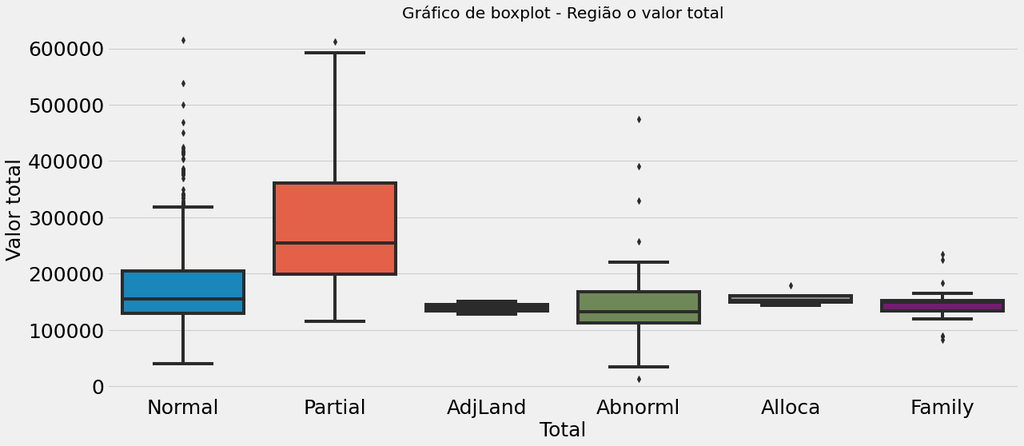

```python
# Verificando os dados no boxplot valor total verificando possíveis outliers

plt.figure(figsize=(18.2, 8))
ax = sns.boxplot(x="Sale.Condition", y="price", data = data_train)
plt.title("Gráfico de boxplot - Região o valor total")
plt.xlabel("Total")
plt.ylabel("Valor total")
```

```python
# Cálculo da média preços dos imóveis

media_preco = data_train[['price', 'MS.SubClass']].groupby('price').mean()
media_area = data_train[["area", "price"]].groupby('price').mean()

print("Média de Preço", media_preco)
print()
print("Média da Idade", media_area)
```

```
Média de Preço         MS.SubClass
price
12789          30.0
34900          30.0
35311          20.0
39300          20.0
40000          70.0
...             ...
535000         60.0
538000         60.0
591587         20.0
611657         20.0
615000         20.0

[535 rows x 1 columns]
```

[output cut: 16 more lines]

# 0.6) Matriz de correlação dos dados

```python
# Matriz correlação de pares de colunas, excluindo NA / valores nulos.

corr = data_train.corr()
corr
```

|  | Unnamed: 0 | PID | area | price | MS.SubClass | Lot.Frontage | Lot.Area | Overall.Qual | Overall.Cond | Year.Built | Year.Remod.Add | Mas.Vnr.Area | BsmtFin.SF.1 | BsmtFin.SF.2 | Bsmt.Unf.SF | Total.Bsmt.SF | X1st.Flr.SF | X2nd.Flr.SF | Low.Qual.Fin.SF | Bsmt.Full.Bath | Bsmt.Half.Bath | Full.Bath | Half.Bath | Bedroom.AbvGr | Kitchen.AbvGr | TotRms.AbvGrd | Fireplaces | Garage.Yr.Blt | Garage.Cars | … |
| --- | --- | --- | --- | --- | --- | --- | --- | --- | --- | --- | --- | --- | --- | --- | --- | --- | --- | --- | --- | --- | --- | --- | --- | --- | --- | --- | --- | --- | --- | --- |
| Unnamed: 0 | 1.000000 | 1.000000 | -0.020591 | -0.023612 | 0.031239 | -0.045722 | -0.027143 | -0.007766 | -0.015206 | 0.028989 | -0.012078 | -0.023815 | -0.017327 | -0.009203 | -0.008799 | -0.030796 | -0.039988 | 0.013664 | -0.016058 | 0.001016 | 0.011608 | -0.001091 | 0.005532 | 0.041937 | 0.043089 | 0.027952 | 0.004405 | 0.051074 | 0.019836 | … |
| PID | 1.000000 | 1.000000 | -0.020591 | -0.023612 | 0.031239 | -0.045722 | -0.027143 | -0.007766 | -0.015206 | 0.028989 | -0.012078 | -0.023815 | -0.017327 | -0.009203 | -0.008799 | -0.030796 | -0.039988 | 0.013664 | -0.016058 | 0.001016 | 0.011608 | -0.001091 | 0.005532 | 0.041937 | 0.043089 | 0.027952 | 0.004405 | 0.051074 | 0.019836 | … |
| area | -0.020591 | -0.020591 | 1.000000 | 0.712738 | 0.074217 | 0.163260 | 0.261350 | 0.612351 | -0.136276 | 0.280975 | 0.376904 | 0.445661 | 0.207924 | -0.063541 | 0.273407 | 0.469721 | 0.573090 | 0.665083 | 0.042654 | 0.092588 | -0.061040 | 0.653455 | 0.454155 | 0.535978 | 0.134593 | 0.811104 | 0.494372 | 0.150978 | 0.534790 | … |
| price | -0.023612 | -0.023612 | 0.712738 | 1.000000 | -0.093181 | 0.207904 | 0.264479 | 0.801749 | -0.136146 | 0.577475 | 0.557502 | 0.540353 | 0.481881 | -0.036420 | 0.191145 | 0.688604 | 0.676856 | 0.240725 | -0.061011 | 0.327629 | -0.061686 | 0.530061 | 0.286355 | 0.140160 | -0.094472 | 0.512586 | 0.505310 | 0.240158 | 0.663864 | … |
| MS.SubClass | 0.031239 | 0.031239 | 0.074217 | -0.093181 | 1.000000 | -0.248543 | -0.182299 | 0.035504 | -0.110207 | 0.061177 | 0.041831 | 0.002055 | -0.071844 | -0.061167 | -0.118613 | -0.218957 | -0.217511 | 0.287051 | -0.009303 | -0.008160 | -0.005745 | 0.138715 | 0.161326 | -0.027990 | 0.262318 | 0.009070 | 0.007334 | -0.092112 | -0.005006 | … |
| Lot.Frontage | -0.045722 | -0.045722 | 0.163260 | 0.207904 | -0.248543 | 1.000000 | 0.129616 | 0.131129 | -0.006577 | 0.040487 | 0.075066 | 0.105377 | 0.060371 | -0.006002 | 0.141039 | 0.203014 | 0.248479 | -0.027125 | -0.036745 | 0.051655 | -0.058904 | 0.067997 | -0.048354 | 0.116606 | 0.046667 | 0.209757 | 0.052330 | 0.025311 | 0.126567 | … |
| Lot.Area | -0.027143 | -0.027143 | 0.261350 | 0.264479 | -0.182299 | 0.129616 | 1.000000 | 0.096424 | -0.048523 | 0.007923 | 0.028049 | 0.117848 | 0.166510 | 0.105498 | 0.032971 | 0.250926 | 0.291020 | 0.047841 | -0.009184 | 0.115156 | 0.059240 | 0.130914 | 0.030376 | 0.153409 | -0.014040 | 0.222573 | 0.232067 | 0.071921 | 0.172780 | … |
| Overall.Qual | -0.007766 | -0.007766 | 0.612351 | 0.801749 | 0.035504 | 0.131129 | 0.096424 | 1.000000 | -0.132045 | 0.604877 | 0.579779 | 0.453385 | 0.282731 | -0.086942 | 0.296183 | 0.562778 | 0.522358 | 0.264008 | -0.082229 | 0.193025 | -0.053768 | 0.544584 | 0.289575 | 0.095550 | -0.123694 | 0.414164 | 0.420019 | 0.262967 | 0.610062 | … |
| Overall.Cond | -0.015206 | -0.015206 | -0.136276 | -0.136146 | -0.110207 | -0.006577 | -0.048523 | -0.132045 | 1.000000 | -0.369617 | 0.023683 | -0.151733 | -0.078013 | 0.011869 | -0.129532 | -0.207914 | -0.177935 | 0.001116 | -0.014914 | -0.053449 | 0.055261 | -0.231755 | -0.096201 | 0.025831 | -0.059146 | -0.066514 | -0.087957 | -0.028095 | -0.225067 | … |
| Year.Built | 0.028989 | 0.028989 | 0.280975 | 0.577475 | 0.061177 | 0.040487 | 0.007923 | 0.604877 | -0.369617 | 1.000000 | 0.616503 | 0.325364 | 0.303653 | -0.017009 | 0.128905 | 0.444709 | 0.343915 | 0.037164 | -0.130762 | 0.231999 | -0.057464 | 0.485527 | 0.279421 | -0.026277 | -0.139474 | 0.135199 | 0.225794 | 0.255551 | 0.558166 | … |
| Year.Remod.Add | -0.012078 | -0.012078 | 0.376904 | 0.557502 | 0.041831 | 0.075066 | 0.028049 | 0.579779 | 0.023683 | 0.616503 | 1.000000 | 0.233025 | 0.170534 | -0.095536 | 0.187837 | 0.331821 | 0.304609 | 0.182503 | -0.090946 | 0.130962 | -0.084661 | 0.481018 | 0.239409 | 0.016679 | -0.143581 | 0.231768 | 0.164680 | 0.154947 | 0.451509 | … |
| Mas.Vnr.Area | -0.023815 | -0.023815 | 0.445661 | 0.540353 | 0.002055 | 0.105377 | 0.117848 | 0.453385 | -0.151733 | 0.325364 | 0.233025 | 1.000000 | 0.293823 | -0.000552 | 0.099250 | 0.410998 | 0.434497 | 0.141613 | -0.049708 | 0.168102 | -0.021755 | 0.290210 | 0.211976 | 0.115525 | -0.055275 | 0.323191 | 0.290557 | 0.116395 | 0.378142 | … |
| BsmtFin.SF.1 | -0.017327 | -0.017327 | 0.207924 | 0.481881 | -0.071844 | 0.060371 | 0.166510 | 0.282731 | -0.078013 | 0.303653 | 0.170534 | 0.293823 | 1.000000 | -0.058193 | -0.490535 | 0.546960 | 0.482305 | -0.182348 | -0.071727 | 0.646861 | 0.066204 | 0.113079 | -0.029799 | -0.097598 | -0.058392 | 0.067827 | 0.321218 | 0.119585 | 0.299054 | … |
| BsmtFin.SF.2 | -0.009203 | -0.009203 | -0.063541 | -0.036420 | -0.061167 | -0.006002 | 0.105498 | -0.086942 | 0.011869 | -0.017009 | -0.095536 | -0.000552 | -0.058193 | 1.000000 | -0.244092 | 0.084312 | 0.066294 | -0.132954 | -0.025438 | 0.156931 | 0.095812 | -0.087104 | -0.037967 | -0.074708 | -0.018933 | -0.092539 | 0.029279 | 0.047916 | -0.031746 | … |
| Bsmt.Unf.SF | -0.008799 | -0.008799 | 0.273407 | 0.191145 | -0.118613 | 0.141039 | 0.032971 | 0.296183 | -0.129532 | 0.128905 | 0.187837 | 0.099250 | -0.490535 | -0.244092 | 1.000000 | 0.385970 | 0.295919 | 0.049374 | 0.063472 | -0.378378 | -0.133120 | 0.278373 | 0.020672 | 0.214638 | 0.073868 | 0.279820 | 0.006171 | 0.014367 | 0.189182 | … |
| Total.Bsmt.SF | -0.030796 | -0.030796 | 0.469721 | 0.688604 | -0.218957 | 0.203014 | 0.250926 | 0.562778 | -0.207914 | 0.444709 | 0.331821 | 0.410998 | 0.546960 | 0.084312 | 0.385970 | 1.000000 | 0.834139 | -0.195961 | -0.022460 | 0.368626 | -0.025688 | 0.364850 | -0.025741 | 0.082287 | 0.004647 | 0.316159 | 0.358471 | 0.160004 | 0.494461 | … |
| X1st.Flr.SF | -0.039988 | -0.039988 | 0.573090 | 0.676856 | -0.217511 | 0.248479 | 0.291020 | 0.522358 | -0.177935 | 0.343915 | 0.304609 | 0.434497 | 0.482305 | 0.066294 | 0.295919 | 0.834139 | 1.000000 | -0.223527 | -0.022835 | 0.309906 | -0.013405 | 0.394411 | -0.071146 | 0.145568 | 0.107778 | 0.428560 | 0.440702 | 0.152456 | 0.498763 | … |
| X2nd.Flr.SF | 0.013664 | 0.013664 | 0.665083 | 0.240725 | 0.287051 | -0.027125 | 0.047841 | 0.264008 | 0.001116 | 0.037164 | 0.182503 | 0.141613 | -0.182348 | -0.132954 | 0.049374 | -0.195961 | -0.223527 | 1.000000 | -0.043707 | -0.165002 | -0.057989 | 0.420650 | 0.609543 | 0.504832 | 0.064337 | 0.572270 | 0.190554 | 0.047370 | 0.190865 | … |
| Low.Qual.Fin.SF | -0.016058 | -0.016058 | 0.042654 | -0.061011 | -0.009303 | -0.036745 | -0.009184 | -0.082229 | -0.014914 | -0.130762 | -0.090946 | -0.049708 | -0.071727 | -0.025438 | 0.063472 | -0.022460 | -0.022835 | -0.043707 | 1.000000 | -0.054759 | -0.021783 | -0.008124 | -0.036118 | 0.009407 | -0.017351 | 0.035786 | -0.020037 | -0.053068 | -0.062878 | … |
| Bsmt.Full.Bath | 0.001016 | 0.001016 | 0.092588 | 0.327629 | -0.008160 | 0.051655 | 0.115156 | 0.193025 | -0.053449 | 0.231999 | 0.130962 | 0.168102 | 0.646861 | 0.156931 | -0.378378 | 0.368626 | 0.309906 | -0.165002 | -0.054759 | 1.000000 | -0.162013 | 0.035243 | -0.030098 | -0.129635 | 0.014873 | -0.010757 | 0.202046 | 0.058447 | 0.212012 | … |
| Bsmt.Half.Bath | 0.011608 | 0.011608 | -0.061040 | -0.061686 | -0.005745 | -0.058904 | 0.059240 | -0.053768 | 0.055261 | -0.057464 | -0.084661 | -0.021755 | 0.066204 | 0.095812 | -0.133120 | -0.025688 | -0.013405 | -0.057989 | -0.021783 | -0.162013 | 1.000000 | -0.044534 | -0.073312 | 0.033130 | -0.068699 | -0.058351 | 0.077644 | -0.043481 | -0.072125 | … |
| Full.Bath | -0.001091 | -0.001091 | 0.653455 | 0.530061 | 0.138715 | 0.067997 | 0.130914 | 0.544584 | -0.231755 | 0.485527 | 0.481018 | 0.290210 | 0.113079 | -0.087104 | 0.278373 | 0.364850 | 0.394411 | 0.420650 | -0.008124 | 0.035243 | -0.044534 | 1.000000 | 0.171156 | 0.368064 | 0.183998 | 0.528677 | 0.275060 | 0.088534 | 0.482772 | … |
| Half.Bath | 0.005532 | 0.005532 | 0.454155 | 0.286355 | 0.161326 | -0.048354 | 0.030376 | 0.289575 | -0.096201 | 0.279421 | 0.239409 | 0.211976 | -0.029799 | -0.037967 | 0.020672 | -0.025741 | -0.071146 | 0.609543 | -0.036118 | -0.030098 | -0.073312 | 0.171156 | 1.000000 | 0.265282 | -0.088151 | 0.331503 | 0.209129 | 0.108917 | 0.253480 | … |
| Bedroom.AbvGr | 0.041937 | 0.041937 | 0.535978 | 0.140160 | -0.027990 | 0.116606 | 0.153409 | 0.095550 | 0.025831 | -0.026277 | 0.016679 | 0.115525 | -0.097598 | -0.074708 | 0.214638 | 0.082287 | 0.145568 | 0.504832 | 0.009407 | -0.129635 | 0.033130 | 0.368064 | 0.265282 | 1.000000 | 0.281250 | 0.675359 | 0.116984 | -0.030568 | 0.111970 | … |
| Kitchen.AbvGr | 0.043089 | 0.043089 | 0.134593 | -0.094472 | 0.262318 | 0.046667 | -0.014040 | -0.123694 | -0.059146 | -0.139474 | -0.143581 | -0.055275 | -0.058392 | -0.018933 | 0.073868 | 0.004647 | 0.107778 | 0.064337 | -0.017351 | 0.014873 | -0.068699 | 0.183998 | -0.088151 | 0.281250 | 1.000000 | 0.334845 | -0.048302 | -0.147686 | 0.001085 | … |
| TotRms.AbvGrd | 0.027952 | 0.027952 | 0.811104 | 0.512586 | 0.009070 | 0.209757 | 0.222573 | 0.414164 | -0.066514 | 0.135199 | 0.231768 | 0.323191 | 0.067827 | -0.092539 | 0.279820 | 0.316159 | 0.428560 | 0.572270 | 0.035786 | -0.010757 | -0.058351 | 0.528677 | 0.331503 | 0.675359 | 0.334845 | 1.000000 | 0.344465 | 0.091010 | 0.389161 | … |
| Fireplaces | 0.004405 | 0.004405 | 0.494372 | 0.505310 | 0.007334 | 0.052330 | 0.232067 | 0.420019 | -0.087957 | 0.225794 | 0.164680 | 0.290557 | 0.321218 | 0.029279 | 0.006171 | 0.358471 | 0.440702 | 0.190554 | -0.020037 | 0.202046 | 0.077644 | 0.275060 | 0.209129 | 0.116984 | -0.048302 | 0.344465 | 1.000000 | 0.184258 | 0.359829 | … |
| Garage.Yr.Blt | 0.051074 | 0.051074 | 0.150978 | 0.240158 | -0.092112 | 0.025311 | 0.071921 | 0.262967 | -0.028095 | 0.255551 | 0.154947 | 0.116395 | 0.119585 | 0.047916 | 0.014367 | 0.160004 | 0.152456 | 0.047370 | -0.053068 | 0.058447 | -0.043481 | 0.088534 | 0.108917 | -0.030568 | -0.147686 | 0.091010 | 0.184258 | 1.000000 | 0.541785 | … |
| Garage.Cars | 0.019836 | 0.019836 | 0.534790 | 0.663864 | -0.005006 | 0.126567 | 0.172780 | 0.610062 | -0.225067 | 0.558166 | 0.451509 | 0.378142 | 0.299054 | -0.031746 | 0.189182 | 0.494461 | 0.498763 | 0.190865 | -0.062878 | 0.212012 | -0.072125 | 0.482772 | 0.253480 | 0.111970 | 0.001085 | 0.389161 | 0.359829 | 0.541785 | 1.000000 | … |
| Garage.Area | 0.037770 | 0.037770 | 0.495172 | 0.651356 | -0.075807 | 0.153088 | 0.187215 | 0.554655 | -0.211342 | 0.502417 | 0.392518 | 0.397257 | 0.330401 | -0.019759 | 0.175613 | 0.518813 | 0.532405 | 0.112242 | -0.055169 | 0.218777 | -0.067343 | 0.390189 | 0.195757 | 0.084806 | -0.023673 | 0.342340 | 0.331584 | 0.508144 | 0.898903 | … |
| Wood.Deck.SF | -0.030016 | -0.030016 | 0.324186 | 0.375783 | -0.043919 | 0.007960 | 0.110189 | 0.284400 | 0.031897 | 0.265944 | 0.255616 | 0.175074 | 0.257054 | 0.073339 | -0.038598 | 0.262743 | 0.262315 | 0.150862 | -0.027629 | 0.211620 | 0.090504 | 0.243030 | 0.152519 | 0.085058 | -0.074633 | 0.226529 | 0.265535 | 0.140861 | 0.306900 | … |
| Open.Porch.SF | -0.046558 | -0.046558 | 0.324860 | 0.280324 | -0.021215 | 0.009422 | 0.071195 | 0.288378 | -0.106115 | 0.213921 | 0.200847 | 0.127317 | 0.106066 | -0.042039 | 0.181074 | 0.277534 | 0.231627 | 0.181887 | -0.047949 | 0.097903 | -0.048486 | 0.277578 | 0.172121 | 0.084850 | -0.016521 | 0.212214 | 0.133708 | 0.000447 | 0.184301 | … |
| Enclosed.Porch | -0.068406 | -0.068406 | -0.019475 | -0.157917 | -0.061739 | 0.023990 | -0.009849 | -0.169448 | 0.112227 | -0.419769 | -0.250738 | -0.109637 | -0.126008 | 0.023902 | 0.004271 | -0.120095 | -0.100728 | 0.048466 | 0.172319 | -0.098653 | -0.007952 | -0.129774 | -0.101502 | 0.010362 | 0.068090 | -0.003942 | -0.011652 | -0.100904 | -0.146459 | … |
| X3Ssn.Porch | 0.013436 | 0.013436 | -0.003511 | 0.024470 | -0.038413 | 0.035659 | 0.003537 | 0.010932 | 0.014557 | 0.005592 | 0.023674 | 0.004626 | 0.031578 | -0.029011 | 0.012375 | 0.034574 | 0.033494 | -0.035151 | 0.004688 | 0.024556 | -0.005146 | 0.023286 | -0.041481 | -0.049771 | -0.020958 | -0.034305 | -0.004417 | -0.002518 | 0.020525 | … |
| Screen.Porch | -0.036815 | -0.036815 | 0.085007 | 0.117427 | -0.040162 | 0.056245 | 0.069261 | 0.058580 | 0.032772 | -0.025288 | -0.032980 | 0.063152 | 0.104324 | 0.042001 | -0.033803 | 0.093242 | 0.100519 | 0.012263 | -0.020577 | 0.062092 | 0.045155 | 0.002021 | 0.048891 | 0.037151 | -0.044519 | 0.066427 | 0.166185 | 0.058337 | 0.048555 | … |
| Pool.Area | -0.002616 | -0.002616 | 0.114237 | 0.064649 | 0.011001 | 0.050600 | 0.022769 | 0.040823 | -0.048756 | 0.009842 | -0.014175 | 0.028233 | 0.063366 | 0.112281 | -0.038962 | 0.072063 | 0.094246 | 0.050882 | -0.004245 | 0.058999 | 0.200343 | 0.063111 | 0.007234 | 0.040728 | -0.009427 | 0.107609 | 0.183154 | 0.010806 | 0.020923 | … |
| Misc.Val | -0.072846 | -0.072846 | -0.028353 | -0.024794 | -0.044480 | -0.040705 | 0.023922 | -0.018911 | 0.081382 | -0.036214 | 0.006873 | -0.023350 | 0.006115 | -0.002912 | -0.020348 | -0.015034 | -0.018136 | -0.016842 | -0.003811 | -0.020218 | -0.008617 | -0.034878 | -0.014049 | -0.004257 | -0.002468 | -0.014365 | -0.028530 | -0.021246 | -0.048175 | … |
| Mo.Sold | 0.010281 | 0.010281 | 0.071108 | 0.060400 | -0.008898 | 0.044509 | 0.007961 | 0.061253 | 0.000054 | 0.019485 | 0.023159 | 0.004716 | 0.033538 | 0.017206 | -0.005546 | 0.036752 | 0.077990 | 0.012707 | 0.009576 | 0.052365 | 0.010540 | 0.078499 | -0.025388 | 0.041946 | 0.037551 | 0.042810 | 0.038833 | 0.001599 | 0.062751 | … |
| Yr.Sold | -0.012822 | -0.012822 | -0.026313 | -0.032139 | -0.031720 | -0.028398 | -0.019552 | -0.033577 | -0.000137 | -0.021961 | 0.015880 | 0.003766 | -0.008741 | 0.008204 | -0.011475 | -0.017568 | -0.041504 | 0.004871 | 0.013066 | 0.010998 | 0.013253 | -0.007623 | 0.051446 | 0.010689 | -0.003376 | -0.032882 | -0.003872 | 0.007690 | -0.016037 | … |

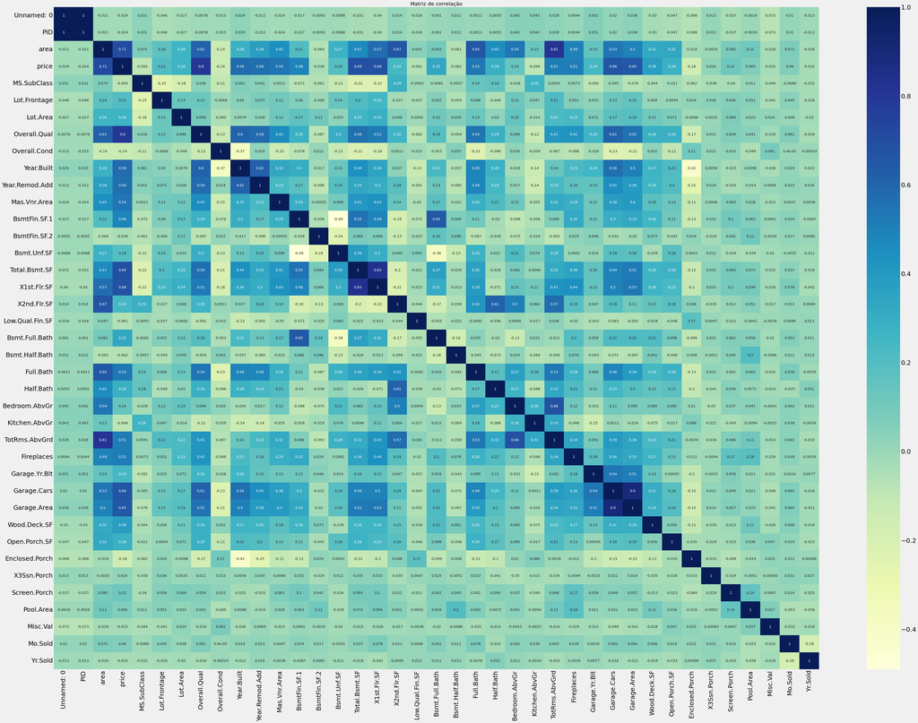

```python
# Gráfico da matriz de correlação

plt.figure(figsize=(60.5,45))
ax = sns.heatmap(data_train.corr(), annot=True, cmap='YlGnBu');
plt.title("Matriz de correlação")
```

# 0.5) Análise de dados

# Questão 2

Depois de ter explorado completamente, certifique-se de criar pelo menos quatro gráficos que você achou mais informativos durante seu processo de EDA e explique brevemente o que você aprendeu com cada um (por que você achou cada informativo).

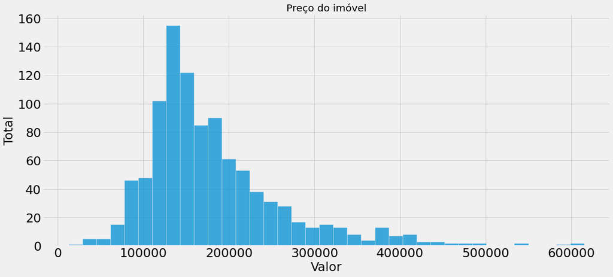

```python
# Observando total dos preços dos imóvel

plt.figure(figsize=(18.2, 8))
sns.histplot(data_train["price"])
plt.title("Preço do imóvel")
plt.xlabel("Valor")
plt.ylabel("Total")
```

[figure not shown]

```python
# Gráfico nascimento das pessoas
plt.figure(figsize=(18.2, 8))

plt.title("Nascimento das pessoas")
ax = sns.histplot(data_train["Year.Built"])
plt.ylabel("Total")
plt.xlabel("Ano")
```

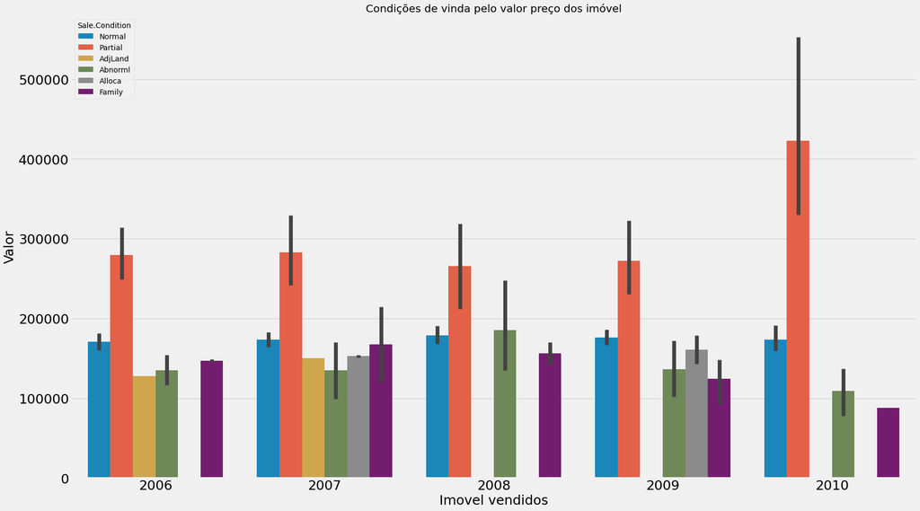

```python
# Gráfico condições de vinda por valor do imóvel
plt.figure(figsize=(25.5, 15))

plt.title("Condições de vinda pelo valor preço dos imóvel")
ax = sns.barplot(x="Yr.Sold", y="price", data = data_train, hue="Sale.Condition")
plt.ylabel("Valor")
plt.xlabel("Imovel vendidos")
```

[figure not shown]

```python
# Região das vendas dos imóveis pela área
plt.figure(figsize=(18.2, 8))

plt.title("Área da cidade")
ax = sns.scatterplot(x="area", y="price", data = data_train, hue = "Sale.Condition")
plt.xlabel("Valor dos imóveis")
plt.ylabel("Valor")
```

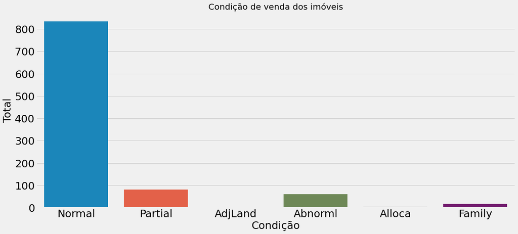

```python
# Gráfico condição de vida das pessoas
plt.figure(figsize=(18.2, 8))

plt.title("Condição de venda dos imóveis")
sns.countplot(data_train["Sale.Condition"])
plt.xlabel("Condição")
plt.ylabel("Total")
```

# 0.6) Análise de dados = Univariada

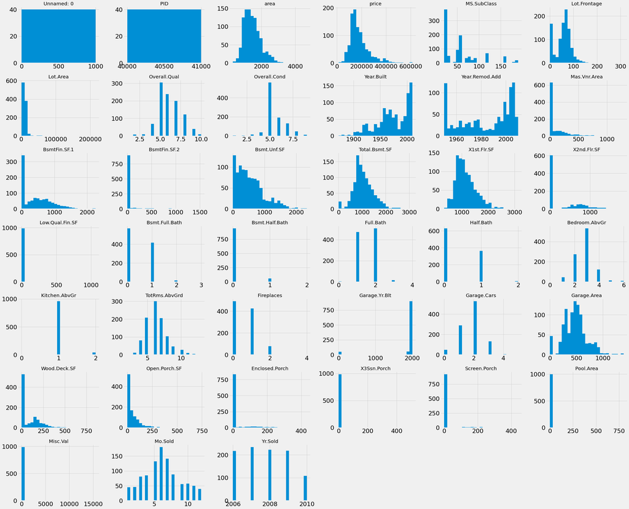

```python
# Fazendo um comparativo dos dados

data_train.hist(bins = 25, figsize=(40.2, 35))
plt.title("Gráfico de histograma")
plt.show()
```

# 0.7) Data Processing

O processamento de dados começa com os dados em sua forma bruta e os converte em um formato mais legível (gráficos, documentos, etc.), dando-lhes a forma e o contexto necessários para serem interpretados por computadores e utilizados.

Exemplo: Uma letra, um valor numérico. Quando os dados são vistos dentro de um contexto e transmite algum significado, tornam-se informações.

```python
# Tipos dos dados
data_test.dtypes
```

[output not shown]

```python
# Mundando os tipo de dados de object para inteiros

data_test['Lot.Area'] = data_test['Lot.Area'].astype(int)
data_test['Yr.Sold'] = data_test['Yr.Sold'].astype(int)
data_test.dtypes
```

```
Unnamed: 0         int64
PID                int64
area               int64
price              int64
MS.SubClass        int64
                   ...
Misc.Val           int64
Mo.Sold            int64
Yr.Sold            int32
Sale.Type         object
Sale.Condition    object
Length: 82, dtype: object
```